# Práctica 9

Author

Ana Mayordomo

## Práctica 9. Reconstrucción filogenética

## Objetivos

Obtener una filogenia calibrada de homininos y algunos primates, a partir de secuencias mitocondriales.

## Ejercicio 1: Leer los datos en R

```r
library(phangorn)
mtdna <- read.phyDat('../../data/mtDNA.fasta', format = 'fasta')
glance(mtdna)
```

```
  nseq nchar unique_site_pattern parsimony_informative_sites const_sites
1   42 16603                 974                        2047       13482
```

##Escoger el modelo de evolución

```r
modelos <- modelTest(mtdna, control = pml.control(trace = 0))
```

## NJ y UPGMA

La función dist.ml() de phangorn solo permite usar distancias de Juke Cantor y de Felsenstein 1981 con ADN. Para usar otros modelos, debemos usar la función dist.dna() del paquete ape (automáticamente cargado con phangorn), que se aplica a objetos de clase DNAbin. Por eso, usamos la función as.DNAbin() para presentarle a dist.dna() los datos en el formato adecuado. En cualquier caso, dist.dna() tampoco implementa todos los modelos.

Ponemos #| fig-width: 5 y #| fig-height: 10 al principio para poder visualizar mejor el árbol que nos ofrece como resultado

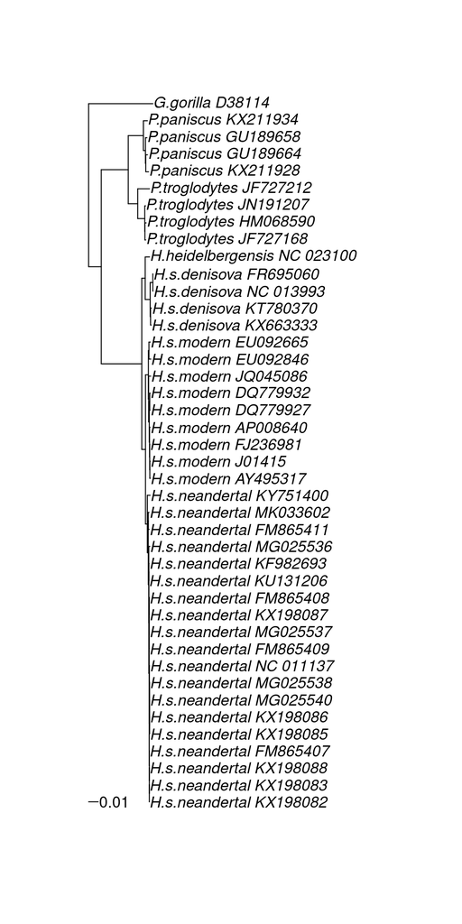

```r
mt_nj    <-    NJ(dist.dna(as.DNAbin(mtdna), model = 'TN93', gamma = 0.93))
mt_upgma <- upgma(dist.dna(as.DNAbin(mtdna), model = 'TN93', gamma = 0.93))
plot(midpoint(mt_nj))
add.scale.bar()
```

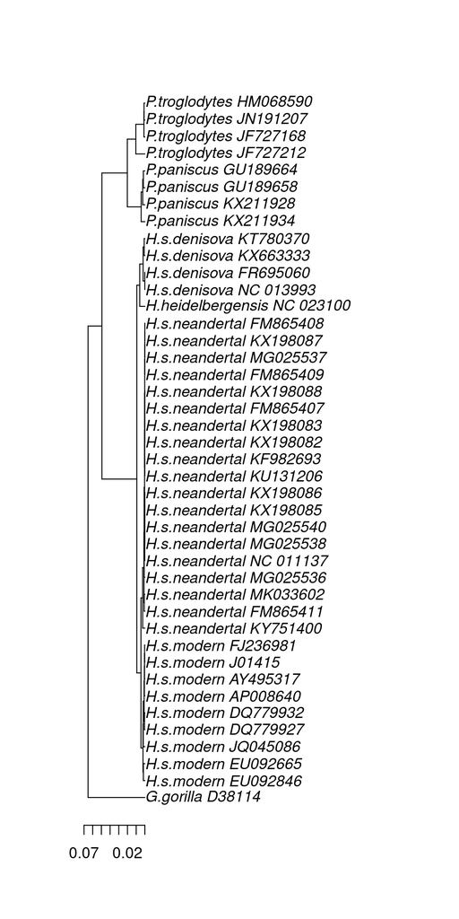

```r
plot(mt_upgma)
axisPhylo()
```

Cuando la función plot() se aplica a un objeto de clase phylo, en realidad se ejecuta la función plot.phylo(). Si quieres explorar las opciones de representación gráfica de árboles con plot(), consulta help(plot.phylo). ¿Por qué usamos midpoint() al representar gráficamente el árbol de NJ? Se usa porque NJ no genera árboles enraizados, asiqe se le aplica una en el punto medio.

##Podemos enraizar el árbol

```r
enraizado <- root(mt_nj, 'G.gorilla_D38114')
```

##Máxima verosimilitud

```r
veros <- pml_bb(mtdna, model = 'GTR+G(4)+I',
                control = pml.control(trace = 0))
```

El objeto veros, de clase pml, contiene el árbol (veros$tree), además de los parámetros optimizados del modelo. Podemos enraizar el árbol usando al gorila como outgroup:

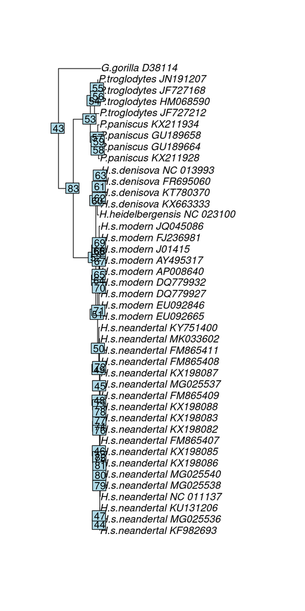

```r
mt_ml <- root(veros$tree, 'G.gorilla_D38114')
plot(midpoint(mt_ml))
nodelabels()
```

También podemos extraer un subárbol para visualizarlo mejor. Con nodelabels() identifico fácilmente cual es el nodo en el que quiero recortar el árbol:

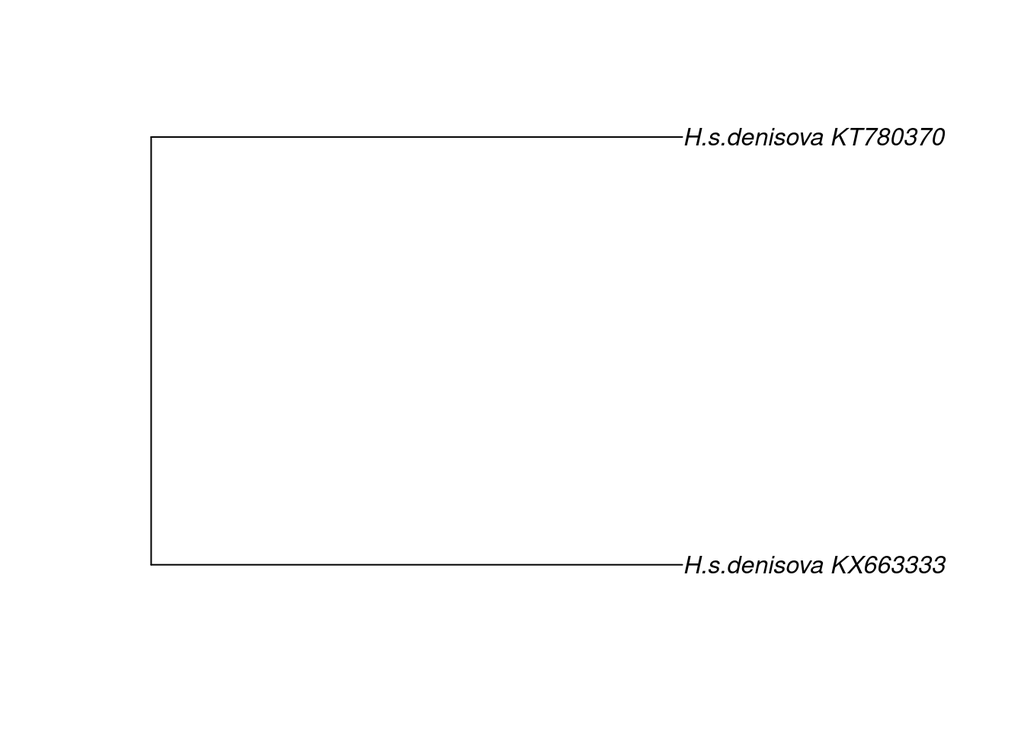

```r
homo <- extract.clade(mt_ml, 62)
plot(midpoint(homo))
```

## Con datación de puntas (tip dating)

Sabiendo que algunas secuencias dejaron de evolucionar hace tiempo (mira el apéndice), podemos intentar calibrar las tasas de sustitución con esta información. Para ello necesitamos un vector de fechas con nombres, donde cada fecha lleva el nombre de la secuencia a la que corresponde. Podemos dar el valor 0 a todas las secuencias contemporáneas y valores negativos, en años, a las secuencias arcaicas.

```r
fechas <- c(0, 0, 0, 0, 0, 0, 0, 0, 0,
              -400000,
              -39000, -50000, -110000, -110000,
              -39820, -40096, -38515, -38310, -39000, -40000, -41210,
              -42430, -42540, -43230, -43780, -44290, -44770, -49000,
              -50000, -82752, -65000, -122287, -110450,
              0, 0, 0, 0, 0, 0, 0, 0, 0)
setNames(fechas, names(mtdna))
```

```
           G.gorilla_D38114      P.troglodytes_JF727212
                          0                           0
     P.troglodytes_JN191207      P.troglodytes_JF727168
                          0                           0
     P.troglodytes_HM068590         P.paniscus_KX211934
                          0                           0
        P.paniscus_KX211928         P.paniscus_GU189658
                          0                           0
        P.paniscus_GU189664 H.heidelbergensis_NC_023100
                          0                     -400000
     H.s.denisova_NC_013993       H.s.denisova_FR695060
                     -39000                      -50000
      H.s.denisova_KX663333       H.s.denisova_KT780370
                    -110000                     -110000
    H.s.neandertal_KX198085     H.s.neandertal_KX198086
                     -39820                      -40096
    H.s.neandertal_MG025538    H.s.neandertal_NC_011137
                     -38515                      -38310
    H.s.neandertal_FM865409     H.s.neandertal_FM865407
                     -39000                      -40000
    H.s.neandertal_KX198088     H.s.neandertal_KX198083
                     -41210                      -42430
    H.s.neandertal_MG025540     H.s.neandertal_MG025536
                     -42540                      -43230
    H.s.neandertal_MG025537     H.s.neandertal_KX198087
                     -43780                      -44290
    H.s.neandertal_KX198082     H.s.neandertal_FM865408
                     -44770                      -49000
    H.s.neandertal_KU131206     H.s.neandertal_KF982693
                     -50000                      -82752
    H.s.neandertal_FM865411     H.s.neandertal_KY751400
                     -65000                     -122287
    H.s.neandertal_MK033602         H.s.modern_EU092846
                    -110450                           0
        H.s.modern_EU092665         H.s.modern_JQ045086
                          0                           0
        H.s.modern_DQ779927         H.s.modern_DQ779932
                          0                           0
        H.s.modern_AP008640         H.s.modern_AY495317
                          0                           0
          H.s.modern_J01415         H.s.modern_FJ236981
                          0                           0
```

```r
fit_td <- pml_bb(mtdna, model = 'GTR+G(4)+I', method = 'tipdated',
                 tree = enraizado,
                 tip.dates = fechas, rearrangement = 'NNI',
                 control = pml.control(trace = 0))
```

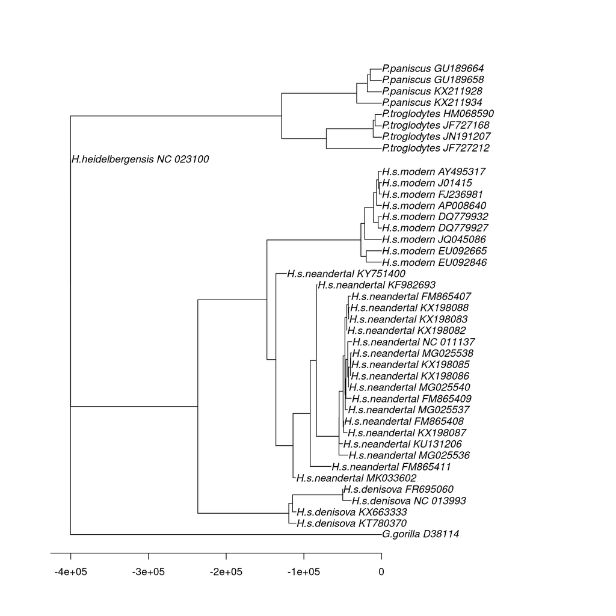

```r
plot(fit_td)
```

Lo que hacemos es obligar a que el árbol sea casi ultramétrico, es decir, que respete las edades.

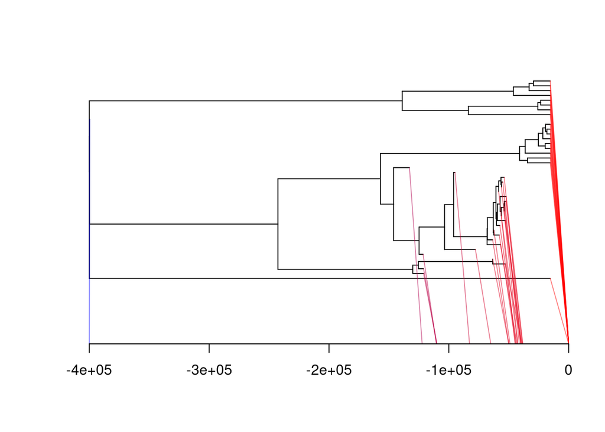

```r
plotTreeTime(fit_td$tree, fechas)
```

```r
estimate.mu(mt_ml, fechas, p.tol = 0.05)
```

```
[1] 2.187596e-08
```

Esto es la tasa de cambio, por cada posición y tasa de tiempo (año)

```r
estimate.dates (mt_ml, fechas, mu = estimate.mu(mt_ml, fechas),
               min.date = .Machine$double.xmax, show.steps = 0,
               opt.tol = 1e-8, nsteps = 1000,
               lik.tol = 0, is.binary.phylo(mt_ml))
```

[output not shown]

[output cut: 946 more lines]

[output not shown]

```
 [1]   0.000000e+00   0.000000e+00   0.000000e+00   0.000000e+00   0.000000e+00
 [6]   0.000000e+00   0.000000e+00   0.000000e+00   0.000000e+00  -4.000000e+05
[11]  -3.900000e+04  -5.000000e+04  -1.100000e+05  -1.100000e+05  -3.982000e+04
[16]  -4.009600e+04  -3.851500e+04  -3.831000e+04  -3.900000e+04  -4.000000e+04
[21]  -4.121000e+04  -4.243000e+04  -4.254000e+04  -4.323000e+04  -4.378000e+04
[26]  -4.429000e+04  -4.477000e+04  -4.900000e+04  -5.000000e+04  -8.275200e+04
[31]  -6.500000e+04  -1.222870e+05  -1.104500e+05   0.000000e+00   0.000000e+00
[36]   0.000000e+00   0.000000e+00   0.000000e+00   0.000000e+00   0.000000e+00
[41]   0.000000e+00   0.000000e+00  8.988466e+307  8.322653e+305  2.219374e+306
[46]  3.329061e+306  1.664531e+306  4.993592e+306  9.987184e+306  1.997437e+307
[51]  3.994874e+307  5.992310e+307  5.992310e+307  2.996155e+307  1.498078e+307
[56]  7.490388e+306  2.996155e+307  1.498078e+307  7.490388e+306  2.996155e+307
[61]  1.997437e+307  9.987184e+306  9.987184e+306  2.663249e+307  8.877497e+306
[66]  1.331625e+307  4.438748e+306  2.219374e+306  1.109687e+306  4.438748e+306
[71]  1.331625e+307  1.109687e+306  1.109687e+306  5.548436e+305  3.698957e+305
[76]  1.849479e+305  9.247393e+304  4.623696e+304  1.849479e+305  9.247393e+304
[81]  4.623696e+304  2.311848e+304
```

estimated.mu es para estimar el reloj molecular estimated.dates Asigna una edad cronológica a los nodos internos del árbol filogenético haciendo una estimación.

Suponemos que el ancestro de chinpances y humanos es de -6.500000 de años. Tenemos que saber en que orden aparcen los nodos.